# Курсовая работа. Блок 1

*Pandas и Matplotlib*

**NB!** Код должен быть с комментариями к каждому логическому блоку кода. В противном случае работа **не** будет принята.  
Выполнение курсовой работы может потребовать использование дополнительных библиотек.

**Описание работы:**

Перед вами стоит бизнес-задача – на основании имеющихся данных подготовить аналитический отчет, который в дальнейшем поможет продюсерам образовательных программ эффективно выстраивать стратегию по модернизированию и улучшению курсов. В начале отчета предлагается оформить емкий описательный блок по каждому курсу на основании рассчитанных показателей. Далее предлагается посчитать потенциальную нагрузку на преподавателей, чтобы оценить необходимость расширения штата сотрудников. Затем идет блок из двух пунктов по анализу качества контента курсов, где необходимо выявить проблемные модули, которые, возможно, требуют доработки. Также стоит задача выявить потенциальную сезонность. Наконец, предложено задание для самостоятельной разработки метрики успеваемости студентов для нахождения тех, кто значительно хуже справляются с прохождением курса. Каждый из пунктов анализа предполагается сопроводить аналитическим выводом на основании рассчитанных метрик.

Обозначения:  
**(p)** – задание может быть выполнено после прохождения модулей по Pandas  
**(m)** – задание может быть выполнено после прохождения модуля по Matplotlib  
⭐ – необязательное задание повышенной сложности

Codebook  
1. Описание и начальная работа с данными  
2. Расчет потенциальной нагрузки на преподавателей  
3. Выявление проблемных модулей  
4. Расчет конверсии  
5. Метрика успеваемости

## Codebook

`courses.csv` содержит следующие значения:  
`id` – идентификатор курса  
`title` – название курса  
`field` – сфера, к которой относится курс  
`students.csv` содержит следующие значения:  
`id` – идентификатор студента  
`city` – город студента  
`birthday` – день рождения студента  
`course_contents.csv` содержит следующие значения:  
`course_id` – идентификатор курса  
`module_number` – номер модуля  
`module_title` – название модуля  
`lesson_number` – номер урока  
`lesson_title` – название урока  
`lesson_token` – токен урока  
`is_video` – наличие видео *(true/false)*  
`is_homework` – наличие домашней работы *(true/false)*  
`progresses.csv` содержит следующие значения:  
`id` – идентификатор прогресса  
`student_id` – идентификатор студента  
`course_id` – идентификатор курса  
`progress_phases.csv` содержит следующие значения:  
`progress_id` – идентификатор прогресса  
`module_number` – номер модуля  
`lesson_number` – номер урока  
`status` – статус прохождения урока  
`start_date` – дата начала  
`finish_date` – дата окончания

## 1. Описание и начальная работа с данными

Вам необходимо подготовить данные и описать их. Данные реальные и содержат пропущенные значения, а также лишние относительно друг друга данные.

Объедините датасеты (кроме `students.scv`) в один общий для дальнейшей работы. Отдельный датасет создайте для расчета среднего возраста студентов курсов (отдельный датасет со `students.scv` нужен, чтобы в основном не потерять значения в основном датасете из-за того, что не по всем студентам есть анкетные данные о дате рождения).  
Опишите данные:

1. **(p)** Посчитайте
   - общее количество курсов в датасете,
   - количество модулей на каждом курсе,
   - количество уроков в каждом модуле на каждом курсе,
   - медианное количество уроков в модуле на каждом курсе,
   - количество учеников на каждом курсе
   - минимальный, максимальный, средний, медианный возраст студентов
   - минимальный, максимальный, средний, медианный возраст студентов на каждом курсе
2. **(m)** Постройте bar-chart, отражающий количество студентов на каждом курсе. Ticks нужно развернуть так, чтобы они были читаемы
3. **(m)** Постройте горизонтальный (столбцы должны располагаться горизонтально) bar-chart, отражающий количество студентов на каждом курсе. График должен иметь заголовок. Значения должны быть отсортированы. Цвет столбцов должен содержать информацию о сфере, к которой относится курс (то есть нужна легенда). Прозрачность должна стоять на отметке 0.1. На график должна быть нанесена линия медианы. У медианы должен быть свой цвет. Рамки у графика быть не должно ⭐
4. На основании рассчитанных значений опишите данные (описание должно быть полным и покрывать все полученные выше метрики)

### 1.0 Первичная обработка данных

```python
# чтение данных и их адаптация для дальнейшей работы

import pandas as pd

courses = pd.read_csv("Data\courses.csv")
course_contents = pd.read_csv("Data\course_contents.csv")
progress_phases = pd.read_csv("Data\progress_phases.csv")
progresses = pd.read_csv("Data\progresses.csv")
students = pd.read_csv("Data\students.csv")


progresses.rename(columns = {'id':'progress_id'}, inplace = True)
courses.rename(columns = {'id':'course_id'}, inplace = True)
N = len(courses)
```

```python
# создание словаря {id_курса:название_курса}

id_title = {courses.iloc[i].course_id:courses.iloc[i].title
            for i in range(N)}
id_title
```

```
{'943306102e5b067d08a29094f37b8193': 'Java-разработчик c нуля',
 '17013cd19d25cb3f28dc1b2683721bb9': 'Веб-дизайн Базовый',
 'ac634845fb0350d0e9d49078aaa4b68f': 'Excel Базовый',
 '0770b1b039964228294f1f34b29fc2c1': 'Руководитель digital-проектов',
 'abce125a877c2196a3bc7bfbc11b5fc5': 'Веб-вёрстка для начинающих 2.0',
 'e9bb9205eeed307ee7cbaa08bfd166c3': 'JavaScript с нуля',
 '04ba6d0b40670c43a209141fa01fa784': 'Анимация интерфейсов',
 'c9fcb746d51e41bc5a217002d081454b': 'Веб-дизайн PRO 2.0',
 'dad6f6ffc086caa89e2f40c28a9c7490': 'UX-дизайн',
 'bf27a4bf4ada4c756451703ea62a914f': 'Интернет-маркетолог от Ingate',
 'e3a0df907589d56692b5cb561fd90d87': 'Веб-дизайн с нуля 2.0',
 '480d25ad36878fce09e7aada316ba1a6': 'Веб-разработчик',
 '842218e7c983795934bbe4533c0888c8': 'SMM-маркетолог от А до Я',
 'ccbab00e99b27f83369d6cc89d914ad6': 'PHP-разработчик с 0 до PRO. Часть 1',
 '6e4837f0a65c68efbfdd0594d6774701': 'Java-разработчик'}
```

```python
# создание словаря {название_курса:сфера_курса}; для графиков

course_field = {courses.iloc[i].title : courses.iloc[i].field
                for i in range(N)}
course_field
```

```
{'Java-разработчик c нуля': 'Development',
 'Веб-дизайн Базовый': 'Design',
 'Excel Базовый': 'Business',
 'Руководитель digital-проектов': 'Business',
 'Веб-вёрстка для начинающих 2.0': 'Development',
 'JavaScript с нуля': 'Development',
 'Анимация интерфейсов': 'Design',
 'Веб-дизайн PRO 2.0': 'Design',
 'UX-дизайн': 'Design',
 'Интернет-маркетолог от Ingate': 'Marketing',
 'Веб-дизайн с нуля 2.0': 'Design',
 'Веб-разработчик': 'Development',
 'SMM-маркетолог от А до Я': 'Marketing',
 'PHP-разработчик с 0 до PRO. Часть 1': 'Development',
 'Java-разработчик': 'Development'}
```

```python
# объединение датасета курсов с датасетом их модулей

courses = pd.merge(courses, course_contents)
del courses['Unnamed: 0']
courses.head()
```

|  | course_id | title | field | module_number | module_title | lesson_number | lesson_title | lesson_token | is_video | is_homework |
| --- | --- | --- | --- | --- | --- | --- | --- | --- | --- | --- |
| 0 | 943306102e5b067d08a29094f37b8193 | Java-разработчик c нуля | Development | 1 | Вводный модуль | 1 | Какие бывают программы | cf394764-8850-4a0a-8d02-03470fe5345c | True | False |
| 1 | 943306102e5b067d08a29094f37b8193 | Java-разработчик c нуля | Development | 1 | Вводный модуль | 2 | Где и для чего применяется Java | b3c2b829-aa3f-4607-a829-b74b69071b19 | True | False |
| 2 | 943306102e5b067d08a29094f37b8193 | Java-разработчик c нуля | Development | 1 | Вводный модуль | 3 | Как выглядит программный код | c25eac6e-b6bb-4de6-957f-f077f07856fc | True | False |
| 3 | 943306102e5b067d08a29094f37b8193 | Java-разработчик c нуля | Development | 1 | Вводный модуль | 4 | Установка среды разработки | 0ac58921-5765-40aa-aec9-544f8313e3f6 | True | False |
| 4 | 943306102e5b067d08a29094f37b8193 | Java-разработчик c нуля | Development | 1 | Вводный модуль | 5 | Исправляем готовое приложение | b28da8d8-0a6e-40bd-b01d-d529d1ad260d | True | False |

```python
# объединеие всех датасеов, кроме students

main = pd.merge(progresses, progress_phases)
main = pd.merge(courses, main)
main.head()
```

|  | course_id | title | field | module_number | module_title | lesson_number | lesson_title | lesson_token | is_video | is_homework | progress_id | student_id | status | start_date | finish_date |
| --- | --- | --- | --- | --- | --- | --- | --- | --- | --- | --- | --- | --- | --- | --- | --- |
| 0 | 943306102e5b067d08a29094f37b8193 | Java-разработчик c нуля | Development | 1 | Вводный модуль | 1 | Какие бывают программы | cf394764-8850-4a0a-8d02-03470fe5345c | True | False | 45cdf025b87db75e84f93c4ac3ccb5c7 | 0b4656b84ca60350583f8fbe236dda86 | done | 2019-03-29 17:02:32.838469+00 | 2019-04-13 17:32:19.134874+00 |
| 1 | 943306102e5b067d08a29094f37b8193 | Java-разработчик c нуля | Development | 1 | Вводный модуль | 1 | Какие бывают программы | cf394764-8850-4a0a-8d02-03470fe5345c | True | False | 0c56109dde49080e7441e95b22bb73c2 | 1d874e6b6bdc34559781f65f9f761791 | done | 2019-06-13 19:22:19.331201+00 | 2019-06-13 19:51:21.987534+00 |
| 2 | 943306102e5b067d08a29094f37b8193 | Java-разработчик c нуля | Development | 1 | Вводный модуль | 1 | Какие бывают программы | cf394764-8850-4a0a-8d02-03470fe5345c | True | False | 36079c0615d85f3cebfa47542b43ab41 | ab7f5c720e3a5e1de00c2cdbef19fbf0 | done | 2019-03-27 06:56:51.138795+00 | 2019-03-27 06:56:54.834751+00 |
| 3 | 943306102e5b067d08a29094f37b8193 | Java-разработчик c нуля | Development | 1 | Вводный модуль | 1 | Какие бывают программы | cf394764-8850-4a0a-8d02-03470fe5345c | True | False | 37384cbeb141835cc61b5fd22abd9200 | 29ab3f8c52a858bea2d3b9a51c433578 | done | 2019-05-28 11:09:29.320478+00 | 2019-05-29 06:47:21.794092+00 |
| 4 | 943306102e5b067d08a29094f37b8193 | Java-разработчик c нуля | Development | 1 | Вводный модуль | 1 | Какие бывают программы | cf394764-8850-4a0a-8d02-03470fe5345c | True | False | 3a79d622c4057c1c029c74e282e43396 | 72afe01498ba14045467fc32029b650c | done | 2019-03-24 07:03:03.582679+00 | 2019-03-24 09:50:32.595199+00 |

**Примечание:**  
*Отдельный датасет для возраста студентов не создавал, так как получилось в той же таблице выполнить рассчеты по возрасту (см. далее).*

### 1.1 Рассчёт показателей

### 1.1.1 Количество курсов в датасете

```python
print(N)
```

```
15
```

### 1.1.2 Количество модулей на каждом курсе

```python
directory = 'CreatedData/'
```

```python
filename = 'NModulesPerCourse.html'
title_modnum = dict() # cловарь {название_курса:количество_модулей}
mod_p_course = pd.DataFrame(columns = ('Название курса', 'Количество модулей'))
for i in id_title.values():
    title_modnum[i] = len(set(courses[courses.title == i].module_title))
    mod_p_course.loc[len(mod_p_course)] = (i, title_modnum[i])
mod_p_course.to_html(directory + filename, index = False)
```

### 1.1.3 Количество уроков в каждом модуле на каждом курсе

```python
filename = 'NLessonsPerModule.html'
les_p_mod = pd.DataFrame(columns = ('Название курса', 'Название модуля',
                                   'Количество уроков'))
course_modules = dict() # словарь {название_курса:[кол-во_уроков_помодульно]}
for course in id_title.values():
    course_modules[course] = []
    for module_number in range(1, title_modnum[course] + 1):
        module_title = list(courses[(courses['module_number'] ==
        module_number) & (courses['title'] ==
        course)].module_title)[0]

        lessons_number = len(courses[(courses['module_number'] ==
        module_number) & (courses['title'] ==
        course)])

        course_modules[course].append(lessons_number)
        les_p_mod.loc[len(les_p_mod)] = (course, module_title, lessons_number)
les_p_mod.set_index(['Название курса', 'Название модуля'], inplace = True)
les_p_mod.to_html(directory + filename)
```

### 1.1.4 Медианное количество уроков в модуле на каждом курсе

```python
from numpy import median
filename = 'MedLessonsPerModule.html'
course_p_med = pd.DataFrame(columns = ('Название курса',
                                       'Медианное кол-во уроков в модуле'))
for i in course_modules:
    course_p_med.loc[len(course_p_med)] = (i, median(course_modules[i]))
course_p_med.to_html(directory+filename, index = False)
```

### 1.1.5 Подсчёт характеристик возрастов всех студентов

```python
# функция для подсчёта возраста студентов из даты рождения

def age(birthday):
    YEAR = 2020
    if (str(birthday) != 'nan'):
        if 12<= (YEAR - int(birthday[:4])) <= 100:
            return YEAR - int(birthday[:4])
    return None
```

```python
students['ages'] = students.birthday.apply(age) # создание столбца ages
students.dropna().head()
```

|  | id_ | id | city | birthday | ages |
| --- | --- | --- | --- | --- | --- |
| 1 | 7503 | 6c3e52be632fc50de9640147e4017dcd | Москва | 1979-10-23 | 41.0 |
| 7 | 11070 | 35a36d90b745992b59085c8d54a072e7 | Красноярск | 1991-08-15 | 29.0 |
| 8 | 11756 | 37e8e8179295ae764524223086b0b568 | Москва | 1987-08-24 | 33.0 |
| 11 | 13568 | fb10649db552c5f451bea45ed754d428 | Санкт-Петербург | 1988-07-16 | 32.0 |
| 15 | 15112 | d15a188c90bb4d83957ac14de78fada4 | Санкт-Петербург | 1991-01-16 | 29.0 |

```python
# отбор валидных значений возраста
correct_ages = list(map(int, students.ages.dropna()))
```

```python
from numpy import mean
filename = 'InfoStudAll.html'
char_value = pd.DataFrame(columns = ('Характеристика', 'Значение'))
char_value.loc[0] = ('Максимальный возраст', max(correct_ages))
char_value.loc[1] = ('Минимальный возраст', min(correct_ages))
char_value.loc[2] = ('Средний возраст', round(mean(correct_ages), 2))
char_value.loc[3] = ('Медианный возраст', median(correct_ages))
char_value.to_html(directory + filename, index = False)
```

### 1.1.6 Подсчёт характеристик возрастов студентов каждого курса

```python
course_studnum = dict() # словарь {название_курса:кол-во_студентов}
filename = 'InfoStudPerCourse.html'
course_stud_info = pd.DataFrame(columns = ('Название курса',
                                           'Количество студентов',
                                           'Максимальный возраст',
                                           'Минимальный возраст',
                                           'Средний возраст',
                                           'Медианный возраст'))
for course in id_title.values():
    studs = list(set(main[main.title == course ]['student_id']))
    course_studnum[course] = len(studs)
    ages_list = [float(students[students.id == i].ages) for i in studs]
    ages_list = [i for i in ages_list if str(i) != 'nan']
    # Максимальное значение
    max_age = max(ages_list)
    # Минимальное значение
    min_age = min(ages_list)
    # Среднее значение
    mean_age = round(mean(ages_list), 2)
    # Медианное значение
    median_age = median(ages_list)
    course_stud_info.loc[len(course_stud_info)] = (course, len(studs), max_age, min_age, mean_age, median_age)
course_stud_info.to_html(directory + filename, index = False)
```

### 1.2 Горизонтальный bar-chart Student = f(Course)

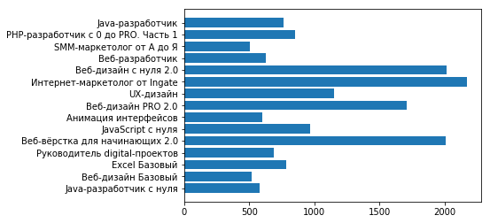

```python
import matplotlib.pyplot as plt

%matplotlib inline
fig, subplot = plt.subplots()
x_ticks, y_ticks = list(course_studnum.keys()), list(course_studnum.values())
subplot.barh(x_ticks, y_ticks)
plt.savefig('CreatedData/course_stud.png', bbox_inches = 'tight')
```

### 1.3 Горизонтальный bar-chart Student = f(Course) с оформлением

```python
# Создаём словарь {сфера:цвет} для дальнейшего окрашивания каждого bar-а
field_color = {'Development': '#1589FF',
               'Design': '#98FF98',
               'Business': '#FFA62F',
               'Marketing': '#F9A7B0'}
```

```python
# Создаём словарь, где значения отсортированы по возрастанию
sorted_dict = {j:i for i, j in course_studnum.items()}
sorted_dict = {sorted_dict[i]:i for i in sorted(sorted_dict)}
```

```python
# Создаём списки обозначений осей
x_ticks, y_ticks = list(zip(*list(sorted_dict.items())))
```

```python
# Создаём список цветов, который соответствует словарю field_color и
# отсортированным значениям x_ticks
color_array = [field_color[course_field[i]] for i in x_ticks]
```

```python
# Определяем медиану для дальнейшего построения её линии
med = median(y_ticks)
```

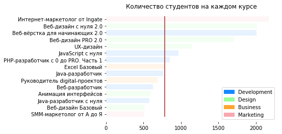

```python
from matplotlib.patches import Rectangle # используется для обозначений легенды
fig, subplot = plt.subplots()

# удаление рамки
subplot.spines['top'].set_visible(False)
subplot.spines['right'].set_visible(False)
subplot.spines['bottom'].set_visible(False)
subplot.spines['left'].set_visible(False)

subplot.barh(x_ticks, y_ticks, color = color_array, alpha = 0.1)

subplot.set_title('Количество студентов на каждом курсе')

# кортеж окрашенных прямоугольников для использования в легенде
rect = tuple(Rectangle((0,0), 10., 5.,
                       color = field_color[i]) for i in field_color)

subplot.legend(rect, tuple(field_color.keys()))

# линия медианы
subplot.vlines(med,-0.4,14.4, color = 'brown')

plt.savefig('CreatedData/course_stud_format.png', bbox_inches = 'tight')
```

### 1.4 Описание полученных данных

1. *Количество курсов*: 15
1. *Количество модулей на каждом курсе:*

   | Название курса | Количество модулей |
   | --- | --- |
   | Java-разработчик c нуля | 9 |
   | Веб-дизайн Базовый | 17 |
   | Excel Базовый | 9 |
   | Руководитель digital-проектов | 17 |
   | Веб-вёрстка для начинающих 2.0 | 8 |
   | JavaScript с нуля | 18 |
   | Анимация интерфейсов | 21 |
   | Веб-дизайн PRO 2.0 | 17 |
   | UX-дизайн | 20 |
   | Интернет-маркетолог от Ingate | 18 |
   | Веб-дизайн с нуля 2.0 | 19 |
   | Веб-разработчик | 20 |
   | SMM-маркетолог от А до Я | 11 |
   | PHP-разработчик с 0 до PRO. Часть 1 | 8 |
   | Java-разработчик | 17 |

1. *Количество уроков в каждом модуле на каждом курсе*:

   | Название курса | Название модуля | Количество уроков |
   | --- | --- | --- |
   | Java-разработчик c нуля | Вводный модуль | 7 |
   |  | Синтаксис языка | 6 |
   |  | Объекты и классы | 10 |
   |  | Числа, строки и даты | 27 |
   |  | Массивы и коллекции | 13 |
   |  | Наследование и полиморфизм | 13 |
   |  | Особенности ООП в Java | 13 |
   |  | Исключения, отладка, тестирование и логгирование | 11 |
   |  | Работа с файлами и сетью | 15 |
   | Веб-дизайн Базовый | Интерфейс. Практика Photoshop | 8 |
   |  | Цели сайта и цели дизайнера | 3 |
   |  | Базовые знания о типографике. Практика Photoshop | 2 |
   |  | Веб-типографика | 1 |
   |  | Основы работы с графикой. Практика Photoshop | 5 |
   |  | Графика для сайтов | 4 |
   |  | Формы и кнопки. Практика Photoshop | 8 |
   |  | Формы и кнопки: интерактивные элементы | 3 |
   |  | Универсальные элементы сайтов. Практика Photoshop | 5 |
   |  | Цвет, атмосфера, тексты и здравый смысл | 3 |
   |  | Интерактивные элементы. Практика Photoshop | 5 |
   |  | Интерактивные элементы | 2 |
   |  | Инфографика. Практика Photoshop | 4 |
   |  | Инфографика: как сделать сайты интересными | 2 |
   |  | Подходя к финишной черте. Практика Photoshop | 2 |
   |  | Финальный день | 1 |
   |  | Дипломная работа | 1 |
   | Excel Базовый | Основной функционал Excel | 11 |
   |  | Основной функционал Excel (продолжение) | 7 |
   |  | Формулы и функции Excel. Введение | 3 |
   |  | Формулы и функции Excel. Продолжаем работать с формулами | 7 |

   [output cut: 199 more lines]

1. *Медианное количество уроков в модуле на каждом курсе*:

   | Название курса | Медианное кол-во уроков в модуле |
   | --- | --- |
   | Java-разработчик c нуля | 13.0 |
   | Веб-дизайн Базовый | 3.0 |
   | Excel Базовый | 5.0 |
   | Руководитель digital-проектов | 5.0 |
   | Веб-вёрстка для начинающих 2.0 | 7.0 |
   | JavaScript с нуля | 7.0 |
   | Анимация интерфейсов | 3.0 |
   | Веб-дизайн PRO 2.0 | 5.0 |
   | UX-дизайн | 3.5 |
   | Интернет-маркетолог от Ingate | 6.5 |
   | Веб-дизайн с нуля 2.0 | 4.0 |
   | Веб-разработчик | 2.0 |
   | SMM-маркетолог от А до Я | 6.0 |
   | PHP-разработчик с 0 до PRO. Часть 1 | 4.0 |
   | Java-разработчик | 7.0 |

1. *Характеристики возрастов всех студентов*:

   | Характеристика | Значение |
   | --- | --- |
   | Максимальный возраст | 100 |
   | Минимальный возраст | 12 |
   | Средний возраст | 29.7 |
   | Медианный возраст | 29 |

   Название курса

   Количество студентов

   Максимальный возраст

   Минимальный возраст

   Средний возраст

   Медианный возраст

   Java-разработчик c нуля

   581

   55.0

   14.0

   30.14

   29.0

   Веб-дизайн Базовый

   518

   51.0

   16.0

   29.18

   28.0

   Excel Базовый

   782

   61.0

   17.0

   34.24

   34.0

   Руководитель digital-проектов

   685

   55.0

   19.0

   32.17

   32.0

   Веб-вёрстка для начинающих 2.0

   2004

   60.0

   14.0

   29.23

   28.0

   JavaScript с нуля

   966

   60.0

   14.0

   29.21

   28.0

   Анимация интерфейсов

   598

   51.0

   15.0

   30.23

   30.0

   Веб-дизайн PRO 2.0

   1711

   59.0

   15.0

   29.09

   28.0

   UX-дизайн

   1151

   85.0

   15.0

   30.81

   30.0

   Интернет-маркетолог от Ingate

   2168

   100.0

   17.0

   31.88

   31.0

   Веб-дизайн с нуля 2.0

   2014

   76.0

   14.0

   28.81

   28.0

   Веб-разработчик

   628

   51.0

   14.0

   28.73

   28.0

   SMM-маркетолог от А до Я

   506

   52.0

   18.0

   29.54

   29.0

   PHP-разработчик с 0 до PRO. Часть 1

   854

   75.0

   14.0

   30.12

   29.0

   Java-разработчик

   763

   65.0

   15.0

   29.94

   29.0

Анализируя *таблицу 6*, можно заметить некую возрастную особенность для каждой профессии. К примеру, средний возраст студентов выше на курсах, связанных с бизнесом. Далее идут маркетологи, следом дизайнеры. А самые молодые изучают программирование. Это служит доказательством того факта, что чем старше люди становятся, тем тяжелее им браться за трудно-осваиваемые, и, в большинстве случаев, целостные профессии. Им нужнее современные инструменты более прикладного характера (как *Excel базовый*), которые помогают им усовершенствовать уже имеюшиеся навыки.

1. *Bar-chart: Количество студентов на каждом курсе*:

[figure not shown]

## 2. Расчет потенциальной нагрузки на преподавателей

1. **(p)** Рассчитать прирост студентов на каждом курсе в каждом месяце за всю историю (каждый месяц в диапазоне от марта 2016 до июля 2019 включительно). Считать дату начала прохождения курса студентом по дате начала первой домашней работы.
2. **(m)** На основании первого пункта построить line-graph с приростом студентов в каждом месяце для каждого курса. 15 графиков. Графики должны иметь заголовки, оси должны быть подписаны. Ticks нужно развернуть так, чтобы они были читаемы.
3. **(m)** На основании первого пункта построить line-graph с несколькими линиями, отражающими прирост студентов в каждом месяце для каждого курса. 15 линий на графике. Ticks нужно развернуть так, чтобы они были читаемы. График должен иметь заголовок. Ось, отражающая прирост, должна быть подписана. Линия для каждого курса должна иметь свой цвет (нужна легенда). Рамок у графика быть не должно ⭐
4. **(p)** Рассчитать количество прогрессов по выполнению домашних работ в каждом месяце за всю историю (каждый месяц в диапазоне от марта 2016 до июля 2019 включительно) для каждого курса. Учитывать, что выполнение домашнего задания может перетекать из одного месяца в другой (такие дз надо включать в общее число прогрессов для всех месяцев, которые покрывает срок выполнения этих дз)
5. **(m)** Построить line-graph по четвертому пункту. 15 графиков. Графики должны иметь заголовки, оси должны быть подписаны. Ticks нужно развернуть так, чтобы они были читаемы
6. **(m)** Построить один line-graph для всех курсов по четвертому пункту. 15 линий на графике. Ticks нужно развернуть так, чтобы они были читаемы. График должен иметь заголовок. Ось, отражающая количество прогрессов, должна быть подписана. Линия для каждого курса должна иметь свой цвет (нужна легенда). Рамок у графика быть не должно ⭐
7. На основании рассчитанных значений сделайте аналитический вывод (должен быть полным и покрывать все полученные выше метрики)

### 2.1 Рассчёт прироста студентов на каждом курсе

```python
directory = 'CreatedData2/'
```

```python
# список нужных месяцев
months = [str(i) + '-' + (j < 10) * '0' + str(j) for i in range(2016, 2020) for j in range(1, 13)]
months = months[months.index('2016-03'):months.index('2019-09')]
month_growth = pd.DataFrame(columns = ('Месяцы', *list(id_title.values())))
month_growth['Месяцы'] = months[:-1]
month_growth.head()
```

|  | Месяцы | Java-разработчик c нуля | Веб-дизайн Базовый | Excel Базовый | Руководитель digital-проектов | Веб-вёрстка для начинающих 2.0 | JavaScript с нуля | Анимация интерфейсов | Веб-дизайн PRO 2.0 | UX-дизайн | Интернет-маркетолог от Ingate | Веб-дизайн с нуля 2.0 | Веб-разработчик | SMM-маркетолог от А до Я | PHP-разработчик с 0 до PRO. Часть 1 | Java-разработчик |
| --- | --- | --- | --- | --- | --- | --- | --- | --- | --- | --- | --- | --- | --- | --- | --- | --- |
| 0 | 2016-03 | NaN | NaN | NaN | NaN | NaN | NaN | NaN | NaN | NaN | NaN | NaN | NaN | NaN | NaN | NaN |
| 1 | 2016-04 | NaN | NaN | NaN | NaN | NaN | NaN | NaN | NaN | NaN | NaN | NaN | NaN | NaN | NaN | NaN |
| 2 | 2016-05 | NaN | NaN | NaN | NaN | NaN | NaN | NaN | NaN | NaN | NaN | NaN | NaN | NaN | NaN | NaN |
| 3 | 2016-06 | NaN | NaN | NaN | NaN | NaN | NaN | NaN | NaN | NaN | NaN | NaN | NaN | NaN | NaN | NaN |
| 4 | 2016-07 | NaN | NaN | NaN | NaN | NaN | NaN | NaN | NaN | NaN | NaN | NaN | NaN | NaN | NaN | NaN |

```python
filename = 'MonthlyGrowth.html'
for course in id_title.values():
    growth = dict() # словарь {'год-месяц':прирост}
    are_homeworks = courses[(courses.title == course) & (courses.is_homework == True)]
    n = len(are_homeworks)
    start_end = ((are_homeworks.iloc[0].module_number,are_homeworks.iloc[0].lesson_number),
                 (are_homeworks.iloc[n - 1].module_number, are_homeworks.iloc[n - 1].lesson_number))
    course_df = main[main.title == course]
    for i, el in enumerate(months[:-1]):
        cur_month = el
        next_month = months[i + 1]
        month_diap = lambda x: (x > cur_month) & (x < next_month)
        # отбор количества начавших и закончивших в этом месяце
        growth[el] = len(course_df[(course_df.module_number == start_end[0][0]) & (course_df.lesson_number == start_end[0][1])
                           & (month_diap(course_df.start_date))])

    month_growth[course] = growth.values()
month_growth.to_html(directory + filename, index = False)
month_growth.tail()
```

|  | Месяцы | Java-разработчик c нуля | Веб-дизайн Базовый | Excel Базовый | Руководитель digital-проектов | Веб-вёрстка для начинающих 2.0 | JavaScript с нуля | Анимация интерфейсов | Веб-дизайн PRO 2.0 | UX-дизайн | Интернет-маркетолог от Ingate | Веб-дизайн с нуля 2.0 | Веб-разработчик | SMM-маркетолог от А до Я | PHP-разработчик с 0 до PRO. Часть 1 | Java-разработчик |
| --- | --- | --- | --- | --- | --- | --- | --- | --- | --- | --- | --- | --- | --- | --- | --- | --- |
| 36 | 2019-03 | 74 | 3 | 63 | 36 | 105 | 57 | 14 | 69 | 39 | 125 | 141 | 9 | 42 | 38 | 74 |
| 37 | 2019-04 | 109 | 5 | 46 | 17 | 91 | 49 | 11 | 56 | 20 | 115 | 118 | 0 | 55 | 32 | 7 |
| 38 | 2019-05 | 74 | 1 | 45 | 25 | 82 | 51 | 10 | 60 | 26 | 140 | 100 | 9 | 56 | 30 | 4 |
| 39 | 2019-06 | 98 | 0 | 43 | 15 | 89 | 34 | 14 | 47 | 48 | 114 | 89 | 3 | 67 | 29 | 4 |
| 40 | 2019-07 | 63 | 2 | 28 | 20 | 72 | 21 | 7 | 40 | 18 | 91 | 76 | 4 | 46 | 15 | 3 |

### 2.2 График ежемесячного прироста студентов на каждом курсе

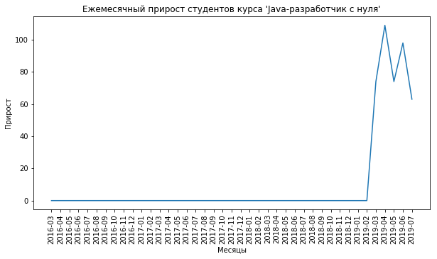

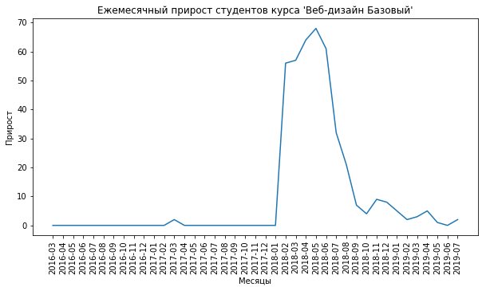

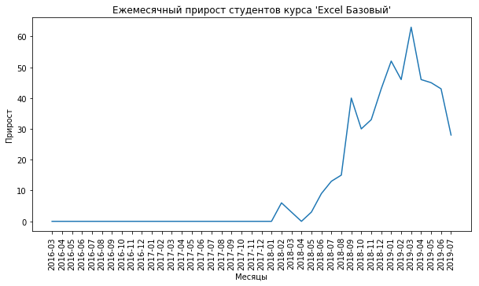

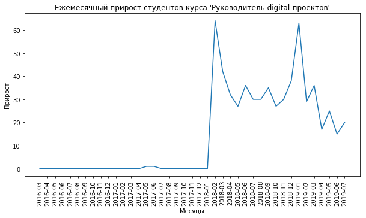

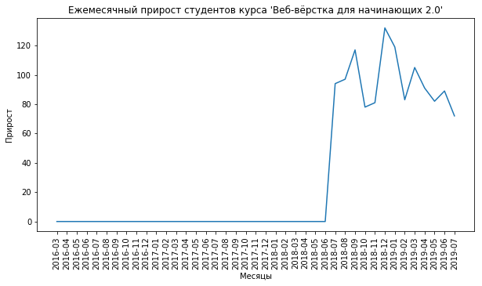

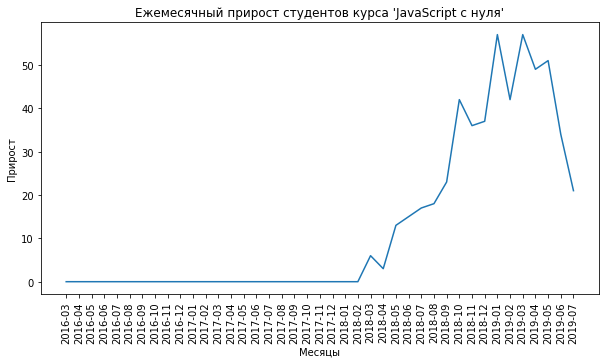

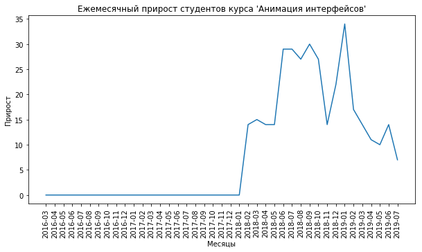

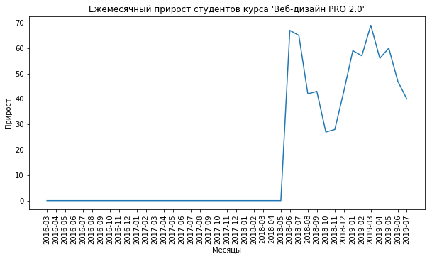

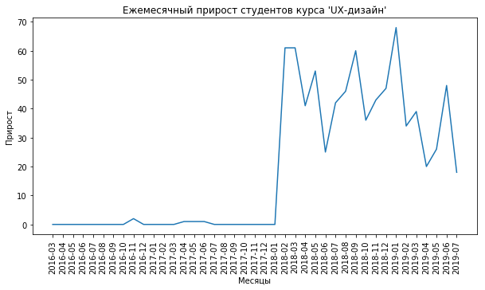

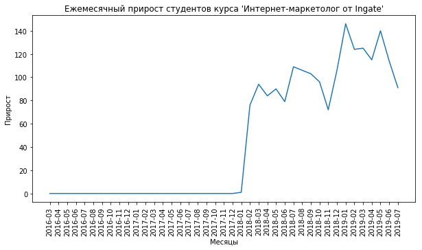

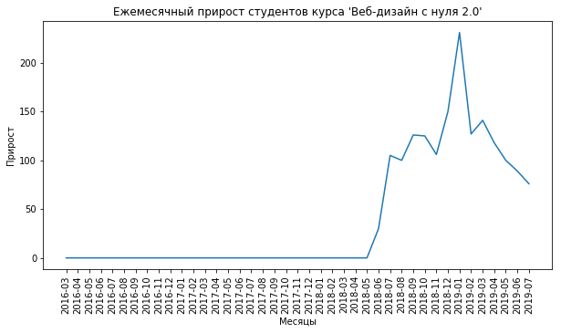

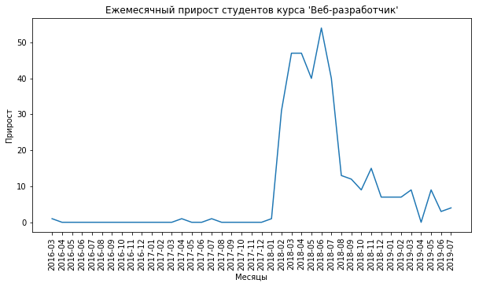

[3 more figures not shown]

```python
from pandas.plotting import register_matplotlib_converters as rmc

rmc()
i = 0
for course in id_title.values():
    i += 1
    filename = 'Course_growth_' + str(i) + '.png'
    fig, subplot = plt.subplots()
    fig.set_size_inches(10, 5)
    subplot.plot(month_growth['Месяцы'], month_growth[course])
    subplot.set_title(f"Ежемесячный прирост студентов курса '{course}'")
    subplot.set_ylabel('Прирост')
    subplot.set_xlabel('Месяцы')
    plt.xticks(month_growth['Месяцы'], rotation = 'vertical')
    plt.savefig(directory + filename, bbox_inches = 'tight')
```

### 2.3 Объединение графиков ежемесячного прироста студентов

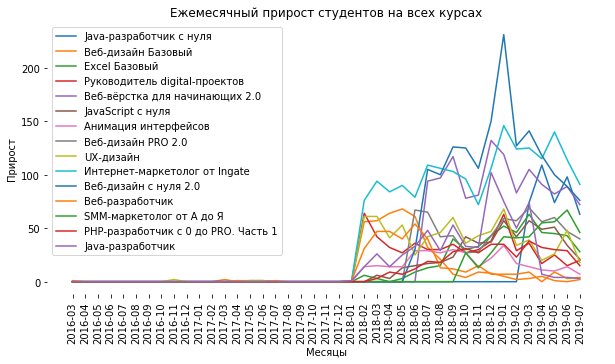

```python
filename = 'All_courses_growth.png'
fig, subplot = plt.subplots()
fig.set_size_inches(10, 5)
for course in id_title.values():
    subplot.plot(month_growth['Месяцы'], month_growth[course])
    subplot.set_title(f"Курс '{course}'")
    plt.xticks(month_growth['Месяцы'], rotation = 'vertical')
subplot.spines['top'].set_visible(False)
subplot.spines['right'].set_visible(False)
subplot.spines['bottom'].set_visible(False)
subplot.spines['left'].set_visible(False)
subplot.set_ylabel('Прирост')
subplot.set_xlabel('Месяцы')
subplot.set_title('Ежемесячный прирост студентов на всех курсах')
subplot.legend()
plt.savefig(directory + filename, bbox_inches = 'tight')
```

```python
filename = 'MonthlyProgress.html'
month_progress = pd.DataFrame(columns = ('Месяцы', *list(id_title.values())))
month_progress['Месяцы'] = months[:-1]
month_progress.head()

# функция для упрощения даты до формата "год-месяц"
cut_month = lambda x: str(x)[:7]

# создание столбцов с упрощенными датами
main['start_month'] = main['start_date'].apply(cut_month)
main['finish_month'] = main['finish_date'].apply(cut_month)

# отбор значений, соответствующих выполненным домашним работам
cur_frame = main[(main.status == 'done') & (main.is_homework == True)]
for month in range(len(months) - 1):
    month_frame = cur_frame[(months[month] >= main.start_month) & (months[month] <= main.finish_month)]
    for course in id_title.values():
        month_progress[course][month] = len(month_frame[month_frame.title == course])
month_progress.to_html(directory + filename, index = False)
month_progress.tail()
```

|  | Месяцы | Java-разработчик c нуля | Веб-дизайн Базовый | Excel Базовый | Руководитель digital-проектов | Веб-вёрстка для начинающих 2.0 | JavaScript с нуля | Анимация интерфейсов | Веб-дизайн PRO 2.0 | UX-дизайн | Интернет-маркетолог от Ingate | Веб-дизайн с нуля 2.0 | Веб-разработчик | SMM-маркетолог от А до Я | PHP-разработчик с 0 до PRO. Часть 1 | Java-разработчик |
| --- | --- | --- | --- | --- | --- | --- | --- | --- | --- | --- | --- | --- | --- | --- | --- | --- |
| 36 | 2019-03 | 87 | 109 | 340 | 348 | 532 | 327 | 141 | 487 | 303 | 751 | 1919 | 74 | 134 | 122 | 469 |
| 37 | 2019-04 | 477 | 98 | 305 | 264 | 473 | 315 | 92 | 448 | 228 | 684 | 1716 | 57 | 160 | 144 | 261 |
| 38 | 2019-05 | 637 | 66 | 289 | 256 | 408 | 308 | 80 | 477 | 195 | 609 | 1394 | 51 | 159 | 130 | 171 |
| 39 | 2019-06 | 924 | 45 | 246 | 172 | 348 | 296 | 72 | 452 | 200 | 618 | 1241 | 41 | 182 | 82 | 102 |
| 40 | 2019-07 | 616 | 24 | 157 | 103 | 141 | 101 | 24 | 173 | 86 | 296 | 458 | 16 | 127 | 29 | 36 |

### 2.5 График количества ежемесячного прогресса по каждому курсу

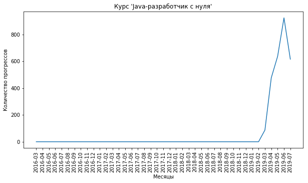

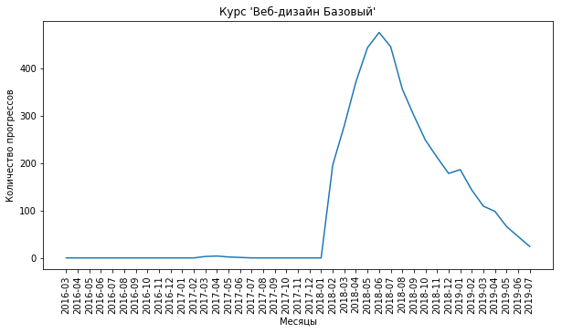

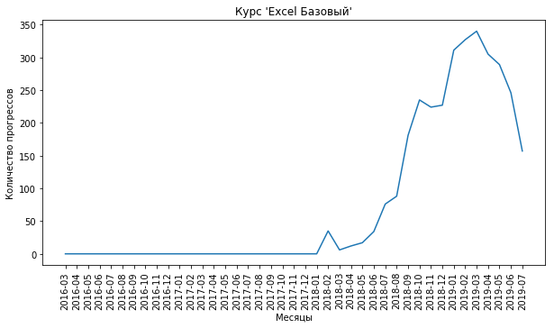

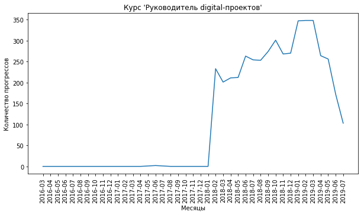

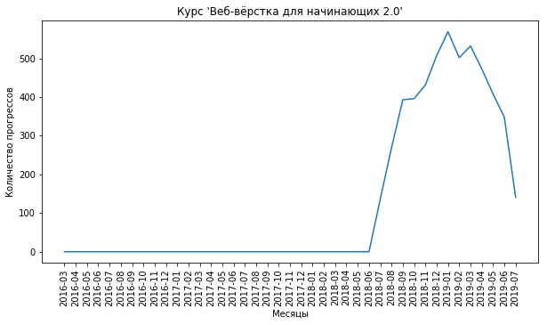

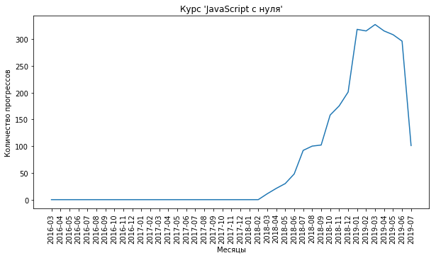

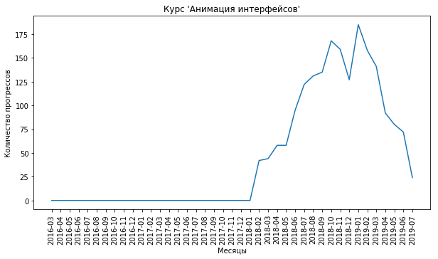

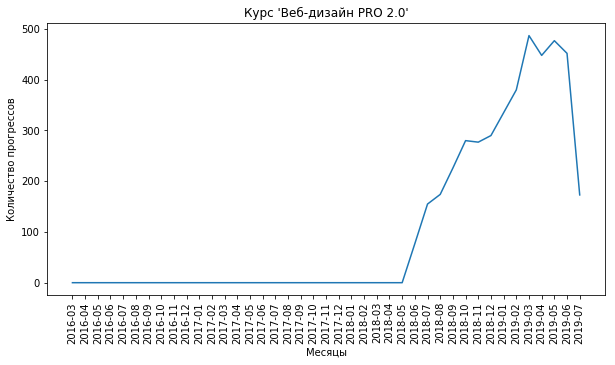

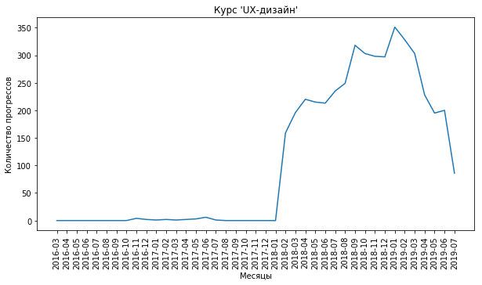

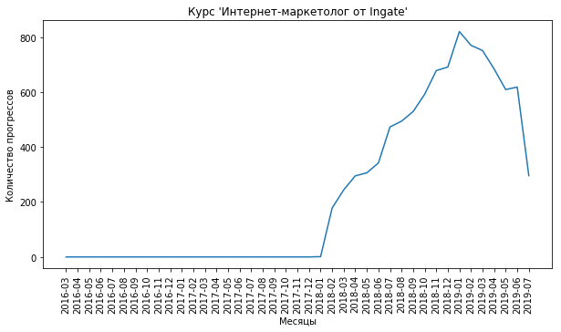

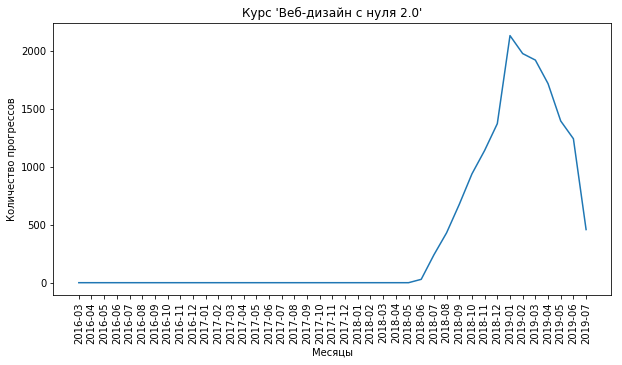

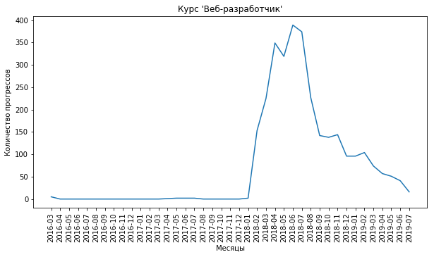

[3 more figures not shown]

```python
rmc()
i = 0
for course in id_title.values():
    i += 1
    filename = 'Course_progress_' + str(i) + '.png'
    fig, subplot = plt.subplots()
    fig.set_size_inches(10, 5)
    subplot.plot(month_progress['Месяцы'], month_progress[course])
    subplot.set_title(f"Курс '{course}'")
    subplot.set_ylabel('Количество прогрессов')
    subplot.set_xlabel('Месяцы')
    plt.xticks(month_progress['Месяцы'], rotation = 'vertical')
    plt.savefig(directory + filename, bbox_inches = 'tight')
```

### 2.6 Объединение графиков количества ежемесячного прогресса

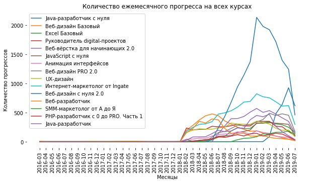

```python
filename = 'All_courses_progress.png'
fig, subplot = plt.subplots()
fig.set_size_inches(10, 5)
for course in id_title.values():
    subplot.plot(month_progress['Месяцы'], month_progress[course])
    plt.xticks(month_progress['Месяцы'], rotation = 'vertical')
subplot.spines['top'].set_visible(False)
subplot.spines['right'].set_visible(False)
subplot.spines['bottom'].set_visible(False)
subplot.spines['left'].set_visible(False)
subplot.set_ylabel('Количество прогрессов')
subplot.set_xlabel('Месяцы')
subplot.set_title('Количество ежемесячного прогресса на всех курсах')
subplot.legend()
plt.savefig(directory + filename, bbox_inches = 'tight')
```

### 2.7 Аналитический вывод

[figure not shown]

## 3. Выявление проблемных модулей

1. **(p)** Рассчитать минимальное, максимальное, среднее, медианное время прохождения каждого модуля (разность между временем начала и окончания выполнения домашней работы) для каждого курса. Если домашних заданий в модуле несколько, то считать разность между временем начала выполнения первой домашней работы и временем окончания выполнения последней домашней работы в модуле
2. **(m)** На основании первого пункта построить line-graph с медианным временем прохождения каждого модуля для каждого курса. 15 графиков. Графики должны иметь заголовки
3. **(p)** Чтобы выявить сезонность, посчитать медианное время выполнения домашней работы по месяцам (12 месяцев, январь-декабрь) для каждого курса.
4. **(m)** На основании третьего пункта построить line-graph, на который будут нанесены линии для каждого курса с медианным временем выполнения домашней работы по месяцам. 15 линий на графике. График должен иметь заголовок. Ось, отражающая время прохождения, должна быть подписана. Линия для каждого курса должна иметь свой цвет (нужна легенда). Рамок у графика быть не должно ⭐
5. На основании рассчитанных значений сделайте аналитический вывод (должен быть полным и покрывать все полученные выше метрики)